# El grafo aleatorio de Erdos-Renyi

Jesus Eduardo Rodriguez Felices

# Grafos Aleatorios de Erdös-Rényi

En general, un **grafo aleatorio** es un grafo que se escoge de manera aleatoria de una colección de posibles grafos la cual puede ser caracterizada por ciertos parámetros con algún valor fijado. En la teoría de grafos se suele tener como objetivo el relacionar diversas propiedades de grafos, tomando esto en consideración, el objetivo del uso de grafos aleatorios es por lo general la prueba de resultados que cuentan con la siguiente forma: “La propiedad A siempre implica la propiedad B”. Dado que las principales aplicaciones de los grafos yacen en la combinatoria y el análisis de redes, la aplicación de grafos aleatorios permite evaluar situaciones más realistas como se mencionarán posteriormente en este trabajo.

## Un poco de historia

Los modelos Erdös-Rényi constan de 2 modelos para la construcción de grafos aleatorios, y a pesar que a los modelos se les conoce conoce con el nombre de Erdös-Rényi debido a Paul Erdös y Alfred Rényi, ellos solo presentaron uno de los modelos que conforman este grupo de 2 modelos. El segundo modelo fue propuesto por Edgar Gilbert de manera independiente y contemporánea al primer modelo, conocido como $G(n,M)$, que fue propuesto en una serie de papers publicados entre 1959 y 1966, del cual resalta en particular el paper *On the evolution of random graphs* publicado en 1960 para el *Instituto de Matemáticas* de la *Academia Húngara de Ciencias*. El segundo modelo, $G(n,p)$, también fue presentado por primera vez en 1959, aunque el crédito por sacar a la luz el tema de grafos aleatorios se le atribuye claramente a Erdös y Rényi.

## Los modelos Erdos-Renyi

Como se mencionó recientemente, se cuentan con dos modelos para la construcción de grafos aleatorios, comenzaremos presentando **el primer modelo**, $G(n,M)$.

**Definición 1:** *(Primer Modelo)* $G(n,M)$ es un grafo que se obtiene de un muestro uniforme de la colección que contiene a todos los grafos con $n$ vértices y $M$ aristas.

Sin embargo, en el paper publicado por Erdös y Rényi en 1960 se incluye otro punto de vista ligeramente diferente para definir un grafo aleatorio del cual podemos conseguir algunas ventajas.

**Definición 2:** *(Primer Modelo)* Consideremos la formación de un grafo aleatorio como un proceso estocástico definido de la siguiente manera: En el tiempo $t = 1$ se escoge una de las $\binom{n}{2}$ posibles aristas (donde $n$ es la cantidad de vértices del grafo), cada una de las aristas con igual probabilidad de ser escogida. Continuando con este proceso al tiempo $t = k+1$ se escoge entre una de las $\binom{n}{2}-k$ posibles aristas que aún no han sido escogidas hasta que se haya escogido las $M$ aristas deseadas para el grafo. Denotamos con $G(n,M)$ al grafo obtenido de este proceso.

Ambas definiciones son equivalentes, sin embargo, la segunda definición permite estudiar lo que se conoce como la *evolución* de un grafo aleatorio, esto es, el desarrollo paso a paso de la estructura de $G(n,M)$ a medida que $M$ aumenta, lo cual se puede emplear para estudiar la evolución de redes de comunicación.

La definición más conocida del **segundo modelo** hace énfasis en la construcción del grafo aleatorio al igual que esta segunda definición recién presentada.

**Definición 3:** *(Segundo Modelo)* $G(n,p)$, con $0\leq p\leq 1$, es un grafo aleatorio obtenido la siguiente manera: Se comienza con un conjunto de vértices $V=\{1,2,3,\dots,n\}$ y se procede a conectar cada par de vértices $\{i,j\}$ con una arista con una probabilidad $p$.

## Modelos Erdos-Renyi en R

R cuenta con un paquete para facilitarnos la implementación de algoritmos que involucren el uso de grafos, donde por lo general resulta trabajoso la implementación y manipulación de los grafos. El paquete **igraph** nos provee de un conjunto de tipos de datos y funciones para ayudarnos con una rápida manipulación de los grafos, entre sus funciones podemos encontrar una que se encarga de la creación de grafos aleatorios siguiente los modelos erdos-renyi, de esta manera podemos ahorrarnos el problema de implementar los procesos de construcción descritos en las definiciones 2 y 3. A continuación se procederá a mostrar algunos ejemplos de la creación de grafos aleatorios usando la función **erdos.renyi.game()**.

```r
>   # Modelo G(n,N)
>   G1 <- erdos.renyi.game(n = 8, p.or.m = 14, type = "gnm")
>   G2 <- erdos.renyi.game(n = 8, p.or.m = 14, type = "gnm")
>   G1
```

```
IGRAPH U--- 8 14 -- Erdos renyi (gnm) graph
+ attr: name (g/c), type (g/c), loops (g/l), m (g/n)
+ edges:
 [1] 1--2 1--4 3--4 1--5 3--5 1--6 2--6 5--6 2--7 4--7 6--7 2--8 3--8 7--8
```

```r
>   G2
```

```
IGRAPH U--- 8 14 -- Erdos renyi (gnm) graph
+ attr: name (g/c), type (g/c), loops (g/l), m (g/n)
+ edges:
 [1] 1--2 1--3 4--5 2--6 3--6 1--7 2--7 3--7 5--7 6--7 2--8 3--8 4--8 6--8
```

```r
>   # Modelo G(n,p)
>   G3 <- erdos.renyi.game(n = 8, p.or.m = 0.5, type = "gnp")
>   G4 <- erdos.renyi.game(n = 8, p.or.m = 0.5, type = "gnp")
>   G3
```

```
IGRAPH U--- 8 13 -- Erdos renyi (gnp) graph
+ attr: name (g/c), type (g/c), loops (g/l), p (g/n)
+ edges:
 [1] 1--3 2--4 2--5 2--6 4--6 5--6 1--7 2--7 5--7 6--7 1--8 2--8 5--8
```

```r
>   G4
```

```
IGRAPH U--- 8 9 -- Erdos renyi (gnp) graph
+ attr: name (g/c), type (g/c), loops (g/l), p (g/n)
+ edges:
[1] 1--2 2--4 1--7 3--7 4--7 6--7 3--8 4--8 6--8
```

Podemos notar que, en efecto, la generación de los grafos se realiza de manera aleatoria y acorde a los modelos previamente descritos. Sin embargo, la visualización del resultado de esta manera puede no resultar muy agradable para poder apreciar correctamente el grafo, afortudamente contamos con tres maneras de visualizar grafos en R:

Usando **plot.igraph()**.

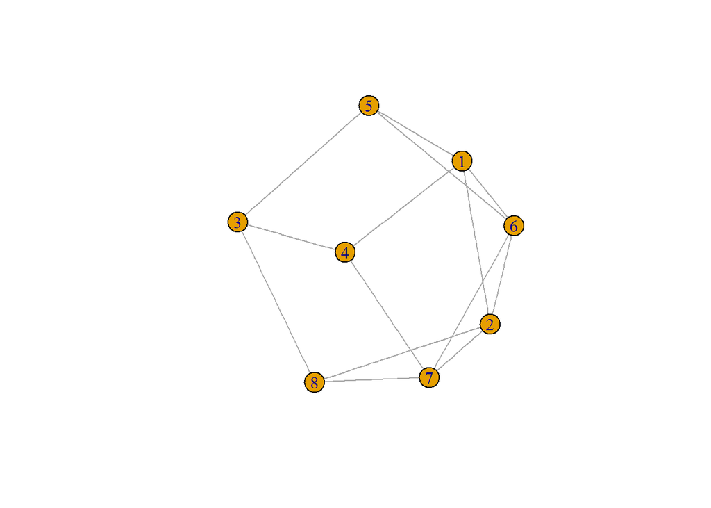

```r
>   plot.igraph(G1)
```

Usando **tkplot()**, la diferencia de este método con el anterior es que este último nos retorna un grafo interactivo en el que podemos mover las posición de los vértices a nuestra conveniencia.

```r
>   tkplot(G2)
```

Desafortudamente el resultado mostrado por tkplot no se puede apreciar en el presente documento de markdown.

Usando **rglplot()**, esta última forma nos muestra un modelo 3d del grafo que podemos rotar y maximizar, aunque la posición de los vértices se encuentre fijo. Para usarlo debemos hacer uso del paquete **rgl**.

```r
>   rglplot(G3)
>   # La siguiente instruccion es para poder incluir el modelo 3d en el documento html
>   rglwidget(elementId = "G3_plot3d")
```

[interactive chart not shown]

## Algunas propiedades del modelo G(n,p)

Debido a la definición misma del segundo modelo Erdos-Renyi, resulta bastante sencillo analizar y probar ciertas propiedades del grafo $G(n,p)$ generado.

### Grado de los vértices

Debido a la naturaleza aletoria del grafo, el grado de cualquier vértice puede ser expresado como una variable aleatoria $X$ cuya distribución resulta sencilla de encontrar. Sea $G(n,p)$ un grafo resultante del segundo modelo Erdos-Renyi, notemos que cualquier vértice $v$ tiene la posibilidad de ser conectado con cualquiera de los otros $n-1$ vértices (en caso que no consideremos lazos) con una probabilidad $p$. Entonces el grado del vértice $X$ puede ser expresando como la suma de $n-1$ variables aleatorias con distribución de bernoulli de probabilidad de éxito $p$, en consecuencia, $X$ tiene una distribución binomial de parámetros $n-1$ y $p$.

Teniendo la dsitribución del grado de los vértices, podemos aprovechar los datos conocidos de dicha distribución para obtener más información sobre el grado de los vértices $X$.
$$\mathbb{P}\{X = x\} = \binom{n-1}{x}p^x(1-p)^{n-1-x},\quad x\in\{0,1,\dots,n-1\}$$
$$\mathbb{E}[X] = (n-1)p$$
$$Var(X) = (n-1)(1-p)p$$

Podemos usar R para verificar estos resultados mediante un muestreo.

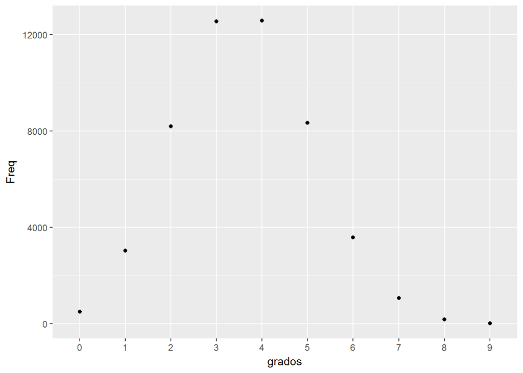

```r
>   # n = 10 y p = 0.4
>   grados <- as.vector(replicate(5000, degree(erdos.renyi.game(10,0.4,"gnp"))))
>   ggplot(data = as.data.frame(table(grados))) + geom_point(mapping = aes(x = grados, y = Freq))
```

```r
>   mean(grados)
```

```
[1] 3.58924
```

```r
>   var(grados)
```

```
[1] 2.148439
```

Donde los resultados de la media y varianza deberían ser aproximadamente $3.6$ y $2.16$ respectivamente.

### Cantidad de Aristas

Siguiendo la misma lógica que usamos para el grado de los vértices podemos probar que la cantidad de aristas $E$ es una variable aleatoria de distribución binomial. Con un total de $n$ vértices, y sin considerar lazos, se pueden generar $\binom{n}{2}$ aristas distintas, si usamos el segundo modelo cada una tendrá $p$ de probabilidad de ser incluída en el grafo. Por tanto, la cantidada de aristas $E$ de $G(n,p)$ tiene una distribución binomial de parámetros $\binom{n}{2}$ y $p$.

Una vez más rescatamos algunas propiedades en base a la distribución.
$$\mathbb{P}\{E = e\} = \binom{\binom{n}{2}}{e}p^e(1-p)^{\binom{n}{2}-e},\quad e\in\left\{0,1,\dots,\binom{n}{2}\right\}$$
$$\mathbb{E}[E] = \binom{n}{2}p$$
$$Var(E) = \binom{n}{2}(1-p)p$$

Probemos estos resultados con otro muestreo en R

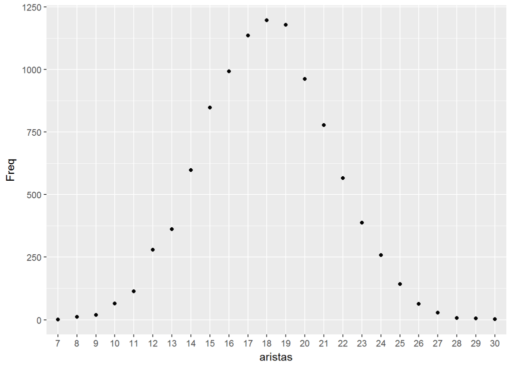

```r
>   # n = 10 y p = 0.4
>   aristas <- (replicate(10000, ecount(erdos.renyi.game(10,0.4,"gnp"))))
>   ggplot(data = as.data.frame(table(aristas))) + geom_point(mapping = aes(x = aristas, y = Freq))
```

```r
>   mean(aristas)
```

```
[1] 17.9945
```

```r
>   var(aristas)
```

```
[1] 10.88876
```

En este caso la media y varianza deberían ser aproximadamente $18$ y $10.8$ respectivamente.

### Local Clustering Coefficient

Presentemos primero le definición de un local clustering coefficient antes de proceder con la propiedad que tiene un grafo $G(n,p)$ respecto a este coeficiente.

**Definición 4:** El *coeficiente de agrupamiento local* o *local clustering coefficient* de un vértice $v$ cuantifica qué tan cerca están sus vecinos de formar un cliqué. Formalmente, sea $N_i$ el conjunto de vecinos de un vertice $v_i$ y $k_i = |N_i|$, el coeficiente de agrupamiento local $C_i$ de $v_i$ está dado por la proporción entre la cantidad de aristas existentes entre los vecinos y el total de aristas que podrían existir. Para un grafo no dirigido tenemos:
$$C_i =\frac{|e_{jk}\in E:v_j,v_k\in N_i|}{\binom{N_i}{2}} = \frac{2|e_{jk}\in E:v_j,v_k\in N_i|}{k_i(k_i-1)}$$

Una vez más, para un grafo $G(n,p)$, el $C_i$ para alguno de sus vértices $v_i$ es una variable aleatoria. Probaremos que $\mathbb{E}[C_i] = p$.

Usemos un teorema análogo a la ley de la probabilidad total llamado **Ley de la esperanza total**, el cual nos indica que si $B_1,...,B_n$ son una partición del espacio muestral, entonces para una variable aleatoria $X$ cualquiera se cumple
$$\mathbb{E}[X]=\sum_{i = 1}^{n}\mathbb{E}(X|B_i)\mathbb{P}\{B_i\}$$

Aplicando a $C_i$ tenemos,
$$\mathbb{E}[C_i]=\sum_{d = 0}^{n-1}\mathbb{E}(C_i|deg(v_i) = d)\mathbb{P}\{deg(v_i)=d\}$$

Observemos que el resultado de la esperanza condicional es simplemente $p$.
$$\mathbb{E}(C_i|deg(v_i) = d)=\frac{p\binom{d}{2}}{\binom{d}{2}} = p$$

La primera igualdad resulta de que el total de aristas posibles entre los $d$ vecinos es $\binom{d}{2}$ y la cantidad de aristas existentes es una variable aleatoria de distribución binomial con parámetros $\binom{d}{2}$ y $p$. En consecuencia, el valoe esperado de $C_i$ se reduce simplemente a:
$$\mathbb{E}[C_i]=p\sum_{d = 0}^{n-1}\mathbb{P}\{deg(v_i)=d\} = p*1 = p$$

Afortudamente, el paquete igraph cuenta con una función llamada *trasitivity()*, la cual puede calcular el coeficiente de agrupamiento local para cada vértice de un grafo dado. Usaremos esta función para probar este resultado con un muestreo.

```r
>   # n = 10 y p = 0.4
>   cc <- as.vector((replicate(5000, transitivity(erdos.renyi.game(10,0.4,"gnp"), type = "local"))))
>   cc <- na.omit(cc)
>   mean(cc)
```

```
[1] 0.4030169
```

Y podemos verificar que la media es aproximadamente igual a la probabilidad $p = 0.4$.

## Evolución de G(n,M)

Como se comentó respecto a la segunda definición del primer modelo, se puede estudiar lo que se conoce como la evolución de un grafo aleatorio $G(n,M)$, este fue el tema central del paper publicado por Erdos y Renyi en 1960 llamado *On the evolution of random graphs*. La evolución de un grafo aleatorio resulta conveniente para evaluar ciertas características que poseerá una red que se encuentre modelada con un grafo a medida que se incrementan la cantidad de interconexiones entre los nodos de la red. A continuación se procederá a describir las 5 fases que fueron presentadas por el trabajo de Erdos y Renyi tomando en consideración que $n$ es un número lo suficientemente grande.

### Primera fase

Esta fase corresponde al rango en el que $M \sim o(n)$. En esta fase,con una probabilidad casi segura, el grafo $G(n,M)$ esta conformado exclusivamente por árboles. A medida que la cantidad de aristas $M$ se acerque a un order de magnitud $n^{\frac{k-2}{k-1}}$, comenzarán a aparecer árboles de orden $k$, es decir, árboles con $k$ vértices. Si
$$M\sim \rho n^{\frac{k-2}{k-1}} \text{ con } \rho >0,$$
entonces la distribución de la cantidad de componentes del grafo $G(n,M)$ que son árboles de orden $k$ tiende a una distribución de Poisson de media $\lambda=\frac{(2\rho)^{k-1}k^{k-2}}{k!}$ cuando $n\rightarrow\infty$.

Si
$$\frac{M}{n^{\frac{k-2}{k-1}}} \longrightarrow \infty,$$
entonces la distribución de la cantidad de componentes que son árboles de orden $k$ para a se aproximadamente normal de media
$$\mu = n\frac{k^{k-2}}{k!}\left( \frac{2M}{n}\right)^{k-1}e^{-\frac{2kM}{n}}$$
y varianza $\sigma^2 = \mu$.

### Segunda fase

Esta fase corresponde al rango en el que $M \sim cn$ con $0<c<1/2$. En esta fase, $G(n,M)$ ya contiene ciclos de cualquier orden fijo que tiene a un límite positivo, la distribución de la cantidad de ciclos de orden $k$ es aproximadamente una distribución de Poisson de media $\lambda = \frac{(2c)^k}{2k}$. En esta fase, es casi seguro que todas las componentes de $G(n,M)$ sean o bien árboles o bien componentes con exactamente un ciclo y además casi todos los vértices pertenecen a componentes que son árboles. La cantidad media de componentes es $n - M + O(1)$, es decir, si se agrega una arista más, la cantidad de componentes disminuirá en 1, aunque esto es sólo para una cantidad finita de veces.

### Tercera fase

Esta fase corresponde al rango en el que $M \sim cn$ con $c\geq1/2$. Cuando $M$ supera el límite de $n/2$, la estructura de $G(n,M)$ cambia abruptamente. Mientras que para $M\sim cn$ con $c < 1/2$ la componente más grande es un árbol con aproximadamente $\frac{1}{\alpha}\left( \log n-\frac{5}{2}\log\log n\right)$ vértices, donde $\alpha = 2c-1-\log 2c$, para $M\sim n/2$ la componente más grande tiene aproximadamente $n^{2/3}$ vértices y una estructura más compleja. Ademá, para $M\sim cn$ con $c> 1/2$ la componente más grande de $G(n,M)$ tiene aproximadamente $G(c)n$ vértices, donde
$$G(c) = 1-\frac{1}{2c}\sum_{k = 1}^{+\infty}\frac{k^{k-1}}{k!}\left( 2ce^{-2c}\right)^k.$$
Notemos que $G(1/2)=0$ y $\lim_{c\rightarrow +\infty}G(c)=1$. A excepción de esta enorme componente todas las otras componentes son relativamente pequeñas y la mayoría de ellas son árboles. La cantidad total de vértices que pertenecen a árboles es, con probabilidad casi segura, $n(1-G(c))+o(n)$ para $c\geq 1/2$.

La cantidad de componentes es asintóticamente igual a $\frac{n}{2c}\left(X(c) - \frac{X^2(c)}{2}\right)$, donde
$$X(c)=\sum_{k = 1}^{+\infty}\frac{k^{k-1}}{k!}\left( 2ce^{2c}\right)^k = 2c(1-G(c))$$

La evolución de $G(n,M)$ en la tercera fase se caracteriza por la absorción de las pequeñas componentes, una luego de otra, por parte de la componente más grande inicialmente descrita. El tiempo de supervivencia de un árbol de orden $k$ en $G(n,M)$ es aproximadamente igual a una distribución exponencial de parámetro $\lambda=\frac{2k}{n}$.

Usemos R para poder visualizar como se incrementa el tamaño de la componente conexa más grande en un grafo $G(n,M)$ durante esta fase. Para ello podemos hacer uso de la función *components()* del paquete igraph, el cual nos da en uno de sus resultados el tamaño de las componentes del grafo.

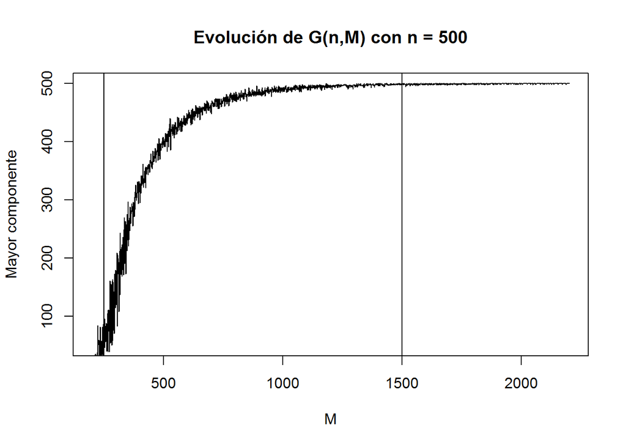

```r
>   plot(c(200,2200), c(50,500), type = "n", xlab = "M", ylab = "Mayor componente")
>   title( main = "Evolución de G(n,M) con n = 500")
>
>   #Delimitamos el rango aproximado para la tercera fase
>   abline(v = c(250, 1500))
>
>   maxComp <- sapply(200:2200, function(x) max(components(erdos.renyi.game(n = 500, p.or.m = x, type = "gnm"))$csize))
>   lines(200:2200, maxComp)
```

Como podemos ver, el tamaño de la componente más grande crece rápidamente al comienzo de esta fase, esto se debe a que como el tiempo de supervivencia de las componentes es una distribución exponencial que depende de su tamaño, las componentes más grandes tienen un menor tiempo de supervivencia esperado y por tanto son las primeras en ser absorvidas por la componente más grande, mientras que las componentes más pequeñas quedan para el final, ocasionando la disminución del ritmo de crecimiento que se aprecia al avanzar en esta fase.

### Cuarta fase

Esta fase corresponde al rango en el que $M \sim cn\log n$ con $c\leq 1/2$. En esta fase es muy probable que el grafo ya se haya vuelto conexo. Si
$$M = \frac{n}{2k}\log n+\frac{k-1}{2k}n\log\log n + yn + o(n),$$
entonces, con una probabilidad que tiene a 1 cuando $n\rightarrow\infty$, sólo quedarán arboles de orden menor o igual a $k$ fuera de la componente más grande. Por tanto, para $k = 1$, es decir,
$$M = \frac{n}{2}\log n + yn + o(n)$$
$G(n,M)$ consiste de una única componente con $n- O(1)$ vértices y un pequeño grupo de puntos aislados.

### Quinta fase

Esta fase corresponde al rango en el que $M \sim (n\log n)\omega(n)$ donde $\omega(n)\rightarrow+\infty$. En este rango, el grafo no solo es seguramente conexo, además los grados de todos los vértices son asintóticamente iguales, por lo que el grafo se vuelve asintóticamente regular.

## Oberservación de la evolución para G(n,p)

Al igual que como hicimos para la tercera fase del modelo $G(n,M)$, podemos usar R para observar el crecimiento de la componente más grande de $G(n,p)$ a medida que incrementamos p, y en base a ello aproximar un probabilidad para la cual se consiga que $G(n,p)$ sea conexo.

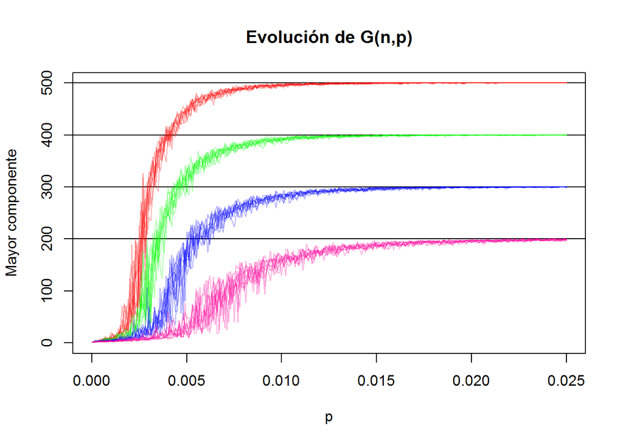

```r
>   plot(c(0,0.025),c(0,500) , type = "n", xlab = "p", ylab = "Mayor componente")
>   title( main = "Evolución de G(n,p)")
>
>   # Delimitamos los valores de n para saber cuando se llega a tener un grafo conexo
>   abline(h = c(200,300,400,500))
>
>   probs <- seq(from = 0, to = 0.025, by = 0.0001)
>
>   # n = 500 : ROJO
>   for(i in 1:10){
+     maxComp <- sapply(probs, function(x) max(components(erdos.renyi.game(n = 500, p.or.m = x, type = "gnp"))$csize))
+     lines(probs, maxComp, col = rgb(1,0,0,alpha = 0.3))
+   }
>
>   # n = 400 : VERDE
>   for(i in 1:10){
+     maxComp <- sapply(probs, function(x) max(components(erdos.renyi.game(n = 400, p.or.m = x, type = "gnp"))$csize))
+     lines(probs, maxComp, col = rgb(0,1,0,alpha = 0.3))
+   }
>
>   # n = 300 : AZUL
>   for(i in 1:10){
+     maxComp <- sapply(probs, function(x) max(components(erdos.renyi.game(n = 300, p.or.m = x, type = "gnp"))$csize))
+     lines(probs, maxComp, col = rgb(0,0,1,alpha = 0.3))
+   }
>
>   # n = 500 : PURPURA
>   for(i in 1:10){
+     maxComp <- sapply(probs, function(x) max(components(erdos.renyi.game(n = 200, p.or.m = x, type = "gnp"))$csize))
+     lines(probs, maxComp, col = rgb(1,0,0.6,alpha = 0.3))
+   }
```

Observemos que a memdida que aumenta el valor de $n$, menor es la probabilidad necesaria para obneter un grafo conexo. Para $n = 500$ basta con una probabilidad aproximadamente de $0.0125$ para obtener un grafo conexo, para $n = 400$ se requiere $p = 0.017$, para $n = 300$ se requiere $p = 0.023$ y para $n = 200$ se requiere $0.0275$. No podemos establecer una relación entre $p$ y $n$ para obtener un grafo conexo guiándonos sólo de las graficas, pero al menos tenemos la certeza de que mantienen una relación inversa. Sin embargo, podemos realizar un análisis superficial para entender el porqué de esta relación inversa.

Rescatemos de la cuarta fase de $G(n,M)$ que para $M\sim \frac{1}{2}n\lg n$, ya es bastante probable que el grafo se haya vuelto conexo. Ahora tomemos la cantidad esperada de aristas para $G(n,p)$, $\binom{n}{2}p \sim \frac{1}{2}n^2p$. Si comparamos ambas aproximaciones obtenemos
$$\frac{1}{2}n^2p \sim \frac{1}{2}n\lg n$$
$$p\sim\frac{\log n}{n}$$

Como es sabido, $\log^k n = o(n)$ para cualquier $k$, por tanto se cumple que a medida que $n$ aumenta, $p$ tiene que disminuir para poder mantener dicha relación.

## Campos de Aplicación

El uso de grafos aleatorios en general encuentran importantes aplicaciones en la combinatoria y análisis de redes.

En combinatoria, lo usual es preguntarse si existe un grafo con ciertas propiedades. Tomemos como ejemplo el número cromático de un grafo, el problema de determinar si un grafo puede ser coloreado con una cantidad fija de colores es de complejidad NP-Hard pues no tiene un algoritmo conocido eficiente para ello. La intuición nos dice que la cantidad de colores necesarios para colorear un grafo disperso debería ser menor que para un grafo denso. Una forma de medir que tan disperso es un grafo es midiendo la longitud de su ciclo más pequeño, a esta medida se lo conoce como cintura (girth). Sin embargo, Paul Erdos llegó a probar usando grafos aleatorios que para cualquier elección de enteros $g$ y $k$, existen grafos con una cintura mayor o igual a $g$ que no pueden ser coloreados con menos de $k$ colores.

Con respecto al análisis de redes, el uso de grafos aleatorios puede ayudar a prever algunas características y tendencias que se puedan presentar a medida que la red crece. También son útiles para identificar anomalías que lleguen a alejar significativamente a la red del modelo esperado.

Por lo general, los modelos Erdös-Rényi son aplicados en el campo donde se busca encontrar modelos generativos para la información con prinpios teóricos, si algo se puede modelar con grafos Erdös-Rényi, entonces es altamente estructurado y esencialemente aleatorio. Tomemos como ejemplo la red de amistades en Facebook, se dice que la mayoría de personas en la red de amistad de un usuario promedio $u$ son esencialmente los mismos y esencialmente aleatorios en las redes de amistad de los amigos de $u$. Aunque ello no sea totalmente cierto, es lo suficientemente adecuado para motivar la investigación de grafos aleatorios para el modelado de esta red de amistades.

## Referencias

- [Paul Erdös, Alfred Rényi, “On the evolution of random graphs” - 1960](http://renyi.mta.hu/~p_erdos/1961-15.pdf).
- [Alan Frieze, Michal Karonski, “Introduction to random graphs”](https://www.math.cmu.edu/~af1p/BOOK.pdf).
- [Jeremy Kun, “The Erdös-Rényi Random Graph”](https://jeremykun.com/2013/08/22/the-erdos-renyi-random-graph/).
- [Geoffrey Fairchild, Jason Fries, “Lecture Notes: Social Networks: Models, Algorithms, and Applications - Lecture 1” - 2012](http://homepage.divms.uiowa.edu/~sriram/196/spring12/lectureNotes/Lecture4.pdf).
- [Paul Erdös, Alfred Rényi, “On Random Graphs I” - 1959](https://gnunet.org/sites/default/files/Erd%C5%91s%20%26%20R%C3%A9nyi%20-%20On%20Random%20Graphs.pdf)
- [Ankur Moitra, “Advaced Algorithms - Lecture 21” - MIT Spring 2016](http://people.csail.mit.edu/moitra/docs/6854notes21.pdf)
- [iGraph Package Documentation](http://igraph.org/r/doc/)
- [Clustering Coefficient - Wikipedia](https://en.wikipedia.org/wiki/Clustering_coefficient#Local_clustering_coefficient)
- [Law of Total Expectation - Wikipedia](https://en.wikipedia.org/wiki/Law_of_total_expectation)